# Deep Learning for TS

In this section we are using Deep Learning methods including an RNN (recurrent neural network), a GRU (Gated Recurrent Unit), and a LSTM (Long Short-Term Memory) to examine the solar radiation data. We are using this specifically because of the amount of data we have - quality data from every day over the lifespan of the data (1998 - 2020).

All code for this tab can be found [here](https://github.com/jsteinfink914/Projects/blob/main/Time%20Series/Deep_Learning.qmd).

## About the Models

Recurrent Neural Networks (RNNs) are a type of neural network designed to handle sequential data by processing the data in a temporal order. They are able to capture temporal dependencies and have been successfully applied in natural language processing, speech recognition, and other sequential tasks.

Long Short-Term Memory (LSTM) and Gated Recurrent Unit (GRU) are two popular variants of RNNs. The key difference between LSTMs and GRUs is the way they handle the memory of the past. LSTMs have a more complex memory structure that includes gates to regulate the flow of information, whereas GRUs have fewer gates and a simpler memory structure.

LSTMs are best suited for tasks that involve long-term dependencies and require the model to retain information over longer sequences. They have been successfully applied in speech recognition, language modeling, and image captioning. GRUs, on the other hand, are a simpler and faster alternative to LSTMs, and are best suited for tasks that require less complex memory structure, such as sentiment analysis, and speech recognition.

Here we will be examining how they perform on 1, 10, and 30 day ahead prediction using the Naive method as a baseline.

## Plotting Data

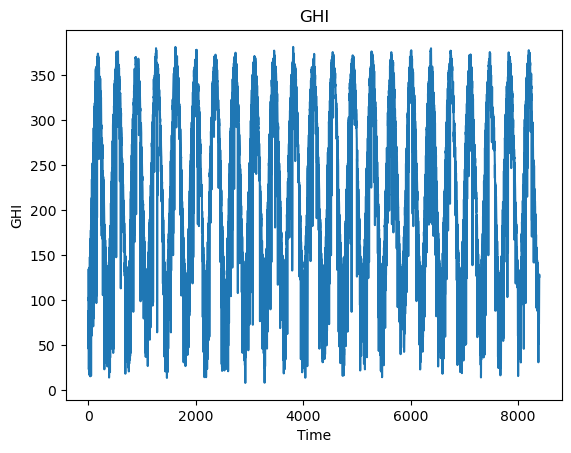

## Normalizing Data

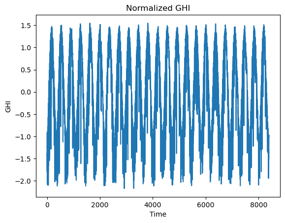

Data normalization is a pre-processing technique commonly used in deep learning to transform input data to have a mean of zero and a standard deviation of one. It is important because it can help accelerate the convergence of the training process, prevent numerical instability, and improve the generalization performance of the model. To perform this type of transformation we simply subtract the data from its mean and divide by its standard deviation. As we can see above the data itself doesn’t look any different it just shrunk to tighter y range.

## 1 Day Ahead Forecasting

### Naive Baseline

```
MAE: 0.2979391902047888
```

Because we normalized data, to make sense of this MAE, we have to multiply by the std of 100.17 which means the average absolute miss from the naive method is about 29.84 watts/$m^2$, approximately half the wattage of a typical lightbulb. This miss is not surprising given the naive approach, and the seasonality in the data.

Now we will look at the deep learning methods to improve upon this.

### Comparing Deep Learning Methods

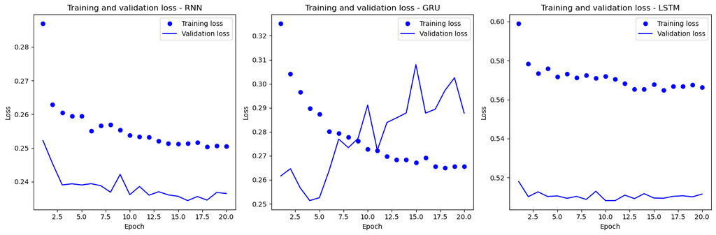

The RNN model generally improves over time and represents a legitimate improvement over the MAE of 0.29 from the naive method. We see slight evidence of overfitting around epoch 9 which gets corrected quickyl and continues its downward trajectory until epoch 16. If we used early stopping, this is where we would have stopped the model during training to prevent overfitting.

The GRU model used dropout to prevent overfitting, which we see still was not enough to prevent this phenomenon. Dropout is a regularization technique used during training of neural networks to prevent overfitting. It works by randomly dropping out (setting to zero) some of the neurons in the network during each training iteration (in this case 20% of them), forcing the remaining neurons to learn more robust and generalized representations. Despite this application, we see overfitting occur at epoch 5 and onwards, while the training loss continues to improve. This indicates that the GRU model is very poor for this data.

The LSTM model shows results that are very similar to the RNN in terms of how the training pattern evolves throughout the epochs, but this is at a much higher loss then the RNN and GRU models.

As a result, for 1 day ahead prediciton, the RNN proved to be the best.

## 10 Day Ahead Forecasting

### Naive Method as A Baseline

```
MAE: 0.37491663547182735
```

The naive method for 10 day ahead forecasting returned an average error of ~ 37.56 watts/$m^2$ off, which is unsurprisingly worse then the 1 day ahead MAE, and what we will be looking to the DL models to improve upon.

### Comparing Deep Learning Models

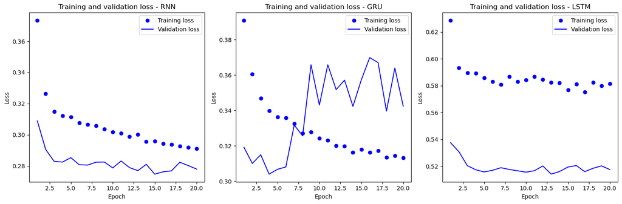

We see very similar patterns in the training runs across all the models with what we saw in the 1 day ahead forecasting. The RNN produced the best results, the GRU quickly began overfitting, and the LSTM did not overfit, but couldn’t compete with the loss of the RNN.

## 30 Day Ahead Forecasting

### Naive Method as a Baseline

```
MAE: 0.5562343444255887
```

The 1 month ahead prediction had an average miss of 55.72 watts/$m^2$.

### Comparing Deep Learning Models

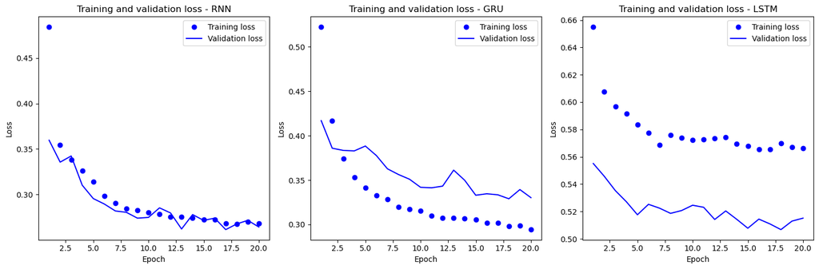

With 30 day ahead predictions we see similar patterns across all the models, different from what we saw before. Here, the GRU does not overfit so badly, while the RNN and LSTM models continue to converge without overfitting. Once again, the RNN is the best performing model without a doubt.

### Comparison to ARIMA

The Arima model returned an MAE of ~20 watts/$m^2$ on 1 day ahead prediction, while the RNN got to about ~25 watts/$m^2$ MAE, indicating that for next day prediction, Arima is superior. However, given the tightness in MAE when we extend the predicition window out, and how poorly the ARIMA models were for further projections, the RNN is definitely the choice when wanting to make a longer term prediction. As always in data science, we need to pick the right tool for the job, and Arima is the right choice due to its simplicity and predictive power in short time spans, while RNN’s are useful for anything more than that.